# `stanova`: User-Friendly Interface and Summaries for Bayesian Statistical Models Estimated with Stan (MathPsych Presentation, 7/2020)

Henrik Singmann

12 July, 2020

# Abstract

Psychological data often consists of multiple orthogonal factors. When analyzing such data with statistical models these factors, like all categorical variables, need to be transformed into numerical covariates using a contrast scheme. To the surprise of many users, the default contrast scheme in the statistical programming language R is such that the intercept is mapped onto the first factor level with the consequence that in models with interactions, coefficients represent simple effects at the first factor level instead of the usually expected average effects. I will present a software package for R, `stanova` (https://github.com/bayesstuff/stanova), that allows estimating statistical models in a Bayesian framework based on Stan and package `rstanarm` that avoids this problem. It by default uses a factor coding proposed by Rouder et al. (2012, JMP) in which the intercept corresponds to the unweighted grand mean and which allows priors that have the same marginal prior on all factor levels. In addition, `stanova` provides a summary method which reports results for each factor level or design cell – specifically the difference from the intercept – instead of for each model coefficient. This also provides a better user experience than the default output of many statistical packages. The talk will show the implementation of the package in R and its adaptation in JASP, an open source alternative to SPSS.

# `stanova`: Overview

## Installation

For the moment, you can only install the development version from [GitHub](https://github.com/bayesstuff/stanova) with:

```r
# install.packages("devtools")
devtools::install_github("bayesstuff/stanova")
```

**For the moment, `stanova` only works with `emmeans` version `1.4.7` or older.** This can be installed via:

```r
devtools::install_version("emmeans", version = "1.4.7", upgrade = "never")
```

All other packages needed here are available from `CRAN`.

# Setup

```r
library("rstanarm")
library("stanova")
library("tidyverse")
theme_set(theme_bw(base_size = 15) +
            theme(legend.position="bottom",
                  panel.grid.major.x = element_blank()))
```

# Example Data

```r
data("fhch2010", package = "afex") ## requires that package afex is installed

fhch <- fhch2010 %>%
  as_tibble() %>%
  filter(correct) %>%
  filter(task == "lexdec") %>%
  droplevels
```

```r
length(unique(fhch$id))
```

```
## [1] 25
```

```r
means <- fhch %>%
  group_by(stimulus, length, id) %>%
  summarise(rt = mean(rt)) %>%
  group_by(stimulus, length) %>%
  summarise(mean_rt = mean(rt),
            se = sd(rt)/sqrt(n()))

means %>%
  select(-se) %>%
  pivot_wider(id_cols = stimulus,
              names_from = length, values_from = mean_rt)
```

```
## # A tibble: 2 x 4
## # Groups:   stimulus [2]
##   stimulus   `4`   `5`   `6`
##   <fct>    <dbl> <dbl> <dbl>
## 1 word      1.08  1.09  1.11
## 2 nonword   1.11  1.16  1.20
```

```r
## row means
means %>%
  select(-se) %>%
  pivot_wider(id_cols = stimulus,
              names_from = length, values_from = mean_rt) %>%
  ungroup %>%
  select(-stimulus) %>%
  rowMeans() %>%
  round(2)
```

```
## [1] 1.10 1.16
```

```r
## column means
means %>%
  select(-se) %>%
  pivot_wider(id_cols = stimulus,
              names_from = length, values_from = mean_rt) %>%
  ungroup %>%
  select(-stimulus) %>%
  colMeans() %>%
  round(2)
```

```
##    4    5    6
## 1.10 1.13 1.16
```

```r
## mean of cell means
mean(means$mean_rt) %>%
  round(2)
```

```
## [1] 1.13
```

```r
a1 <- afex::aov_ez("id", "rt", fhch, within = c("length", "stimulus"))
```

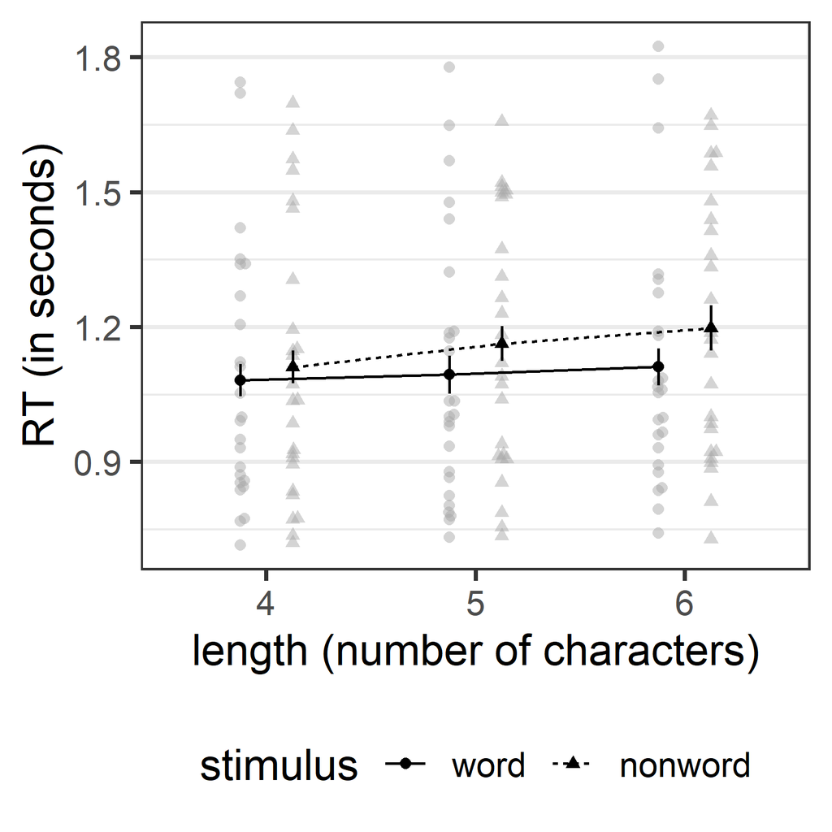

```r
p1 <- afex::afex_plot(a1, "length", "stimulus", error = "within",
                data_geom = ggbeeswarm::geom_beeswarm,
                data_arg = list(
                  dodge.width = 0.5,  ## needs to be same as dodge
                  cex = 0.8,
                  color = "darkgrey"),
                factor_levels = list(
                  length = c(4, 5, 6)
                )) +
  labs(x = "length (number of characters)", y = "RT (in seconds)")
p1
```

```r
p2 <- afex::afex_plot(a1, "length", "stimulus", error = "within",
                data_geom = ggbeeswarm::geom_beeswarm,
                data_arg = list(
                  dodge.width = 0.5,  ## needs to be same as dodge
                  cex = 0.8,
                  color = "darkgrey"),
                factor_levels = list(
                  length = c(4, 5, 6)
                ), point_arg = list(size = 3.5), line_arg = list(size = 1.2),
                error_arg = list(size = 1.2, width = 0)) +
  labs(x = "length (number of characters)", y = "RT (in seconds)") +
  theme_bw(base_size = 20) +
            theme(legend.position="bottom",
                  panel.grid.major.x = element_blank())
ggsave(filename = "example_data.png", plot = p2,
       width = 12, height = 17, units = "cm", dpi = 200)
```

# Using `rstanarm`

## Default (Treatment) Contrasts

```r
m_def <- stan_lmer(rt ~ length*stimulus + (length*stimulus|id), fhch)
summary(m_def, pars = "(Intercept)", regex_pars = c("^length", "^stimulus"),
        digits = 2)
```

```
##
## Model Info:
##  function:     stan_lmer
##  family:       gaussian [identity]
##  formula:      rt ~ length * stimulus + (length * stimulus | id)
##  algorithm:    sampling
##  sample:       4000 (posterior sample size)
##  priors:       see help('prior_summary')
##  observations: 7096
##  groups:       id (25)
##
## Estimates:
##                           mean   sd    10%   50%   90%
## (Intercept)              1.08   0.06  1.01  1.08  1.15
## length5                  0.01   0.02 -0.02  0.01  0.04
## length6                  0.03   0.02  0.00  0.03  0.06
## stimulusnonword          0.03   0.03 -0.01  0.03  0.07
## length5:stimulusnonword  0.04   0.03 -0.01  0.04  0.08
## length6:stimulusnonword  0.06   0.03  0.01  0.06  0.10
##
## MCMC diagnostics
##                         mcse Rhat n_eff
## (Intercept)             0.00 1.01  371
## length5                 0.00 1.00 2472
## length6                 0.00 1.00 2352
## stimulusnonword         0.00 1.00 2093
## length5:stimulusnonword 0.00 1.00 2266
## length6:stimulusnonword 0.00 1.00 2556
##
## For each parameter, mcse is Monte Carlo standard error, n_eff is a crude measure of effective sample size, and Rhat is the potential scale reduction factor on split chains (at convergence Rhat=1).
```

## Sum-To-Zero Contrasts (ANOVA Appropriate)

```r
afex::set_sum_contrasts()
```

```
## setting contr.sum globally: options(contrasts=c('contr.sum', 'contr.poly'))
```

```r
m_sum <- stan_lmer(rt ~ length*stimulus + (length*stimulus|id), fhch)
summary(m_sum, pars = "(Intercept)", regex_pars = c("^length", "^stimulus"),
        digits = 2)
```

```
##
## Model Info:
##  function:     stan_lmer
##  family:       gaussian [identity]
##  formula:      rt ~ length * stimulus + (length * stimulus | id)
##  algorithm:    sampling
##  sample:       4000 (posterior sample size)
##  priors:       see help('prior_summary')
##  observations: 7096
##  groups:       id (25)
##
## Estimates:
##                     mean   sd    10%   50%   90%
## (Intercept)        1.13   0.05  1.06  1.13  1.20
## length1           -0.03   0.01 -0.04 -0.03 -0.02
## length2            0.00   0.01 -0.01  0.00  0.01
## stimulus1         -0.03   0.01 -0.05 -0.03 -0.01
## length1:stimulus1  0.02   0.01  0.00  0.02  0.03
## length2:stimulus1  0.00   0.01 -0.02  0.00  0.01
##
## MCMC diagnostics
##                   mcse Rhat n_eff
## (Intercept)       0.00 1.00  405
## length1           0.00 1.00 4047
## length2           0.00 1.00 4407
## stimulus1         0.00 1.00 1802
## length1:stimulus1 0.00 1.00 2728
## length2:stimulus1 0.00 1.00 5327
##
## For each parameter, mcse is Monte Carlo standard error, n_eff is a crude measure of effective sample size, and Rhat is the potential scale reduction factor on split chains (at convergence Rhat=1).
```

# Model Matrices

```r
df_both <- expand_grid(
  stimulus = sort(unique(fhch$stimulus)),
  length = sort(unique(fhch$length))
)
df_stim <- expand_grid(
  stimulus = sort(unique(fhch$stimulus))
)
df_length <- expand_grid(
  length = sort(unique(fhch$length))
)
```

```r
knitr::kable(cbind(
  df_length,
  model.matrix(~ length, df_length, contrasts.arg = list(length = "contr.treatment"))
))
```

| length | (Intercept) | length5 | length6 |
| --- | --- | --- | --- |
| 4 | 1 | 0 | 0 |
| 5 | 1 | 1 | 0 |
| 6 | 1 | 0 | 1 |

```r
knitr::kable(cbind(
  df_length,
  model.matrix(~ length, df_length, contrasts.arg = list(length = "contr.sum"))
))
```

| length | (Intercept) | length1 | length2 |
| --- | --- | --- | --- |
| 4 | 1 | 1 | 0 |
| 5 | 1 | 0 | 1 |
| 6 | 1 | -1 | -1 |

```r
knitr::kable(cbind(
  df_length,
  model.matrix(~ length, df_length, contrasts.arg = list(length = "contr.bayes"))
))
```

| length | (Intercept) | length1 | length2 |
| --- | --- | --- | --- |
| 4 | 1 | 0.000 | 0.816 |
| 5 | 1 | -0.707 | -0.408 |
| 6 | 1 | 0.707 | -0.408 |

# Using `stanova`

```r
m_stanova <- stanova_lmer(rt ~ length*stimulus + (length*stimulus|id), fhch)
summary(m_stanova, digits = 2)
```

```
##
## Model Info:
##  function:     stanova_glmer
##  family:       gaussian [identity]
##  formula:      rt ~ length * stimulus + (length * stimulus | id)
##  algorithm:    sampling
##  chains:       4
##  sample:       4000 (posterior sample size)
##  priors:       see help('prior_summary', package = 'rstanarm')
##  observations: 7096
##  groups:       id (25)
##
## Estimate Intercept:
##      Variable Mean MAD_SD   5%  50%  95% rhat ess_bulk ess_tail
## 1 (Intercept) 1.13   0.05 1.04 1.12 1.21 1.01   372.52   727.74
##
##
## Estimates 'length' - difference from intercept:
##   Variable  Mean MAD_SD    5%   50%   95% rhat ess_bulk ess_tail
## 1 length 4 -0.03   0.01 -0.05 -0.03 -0.01 1.00  4779.76  3398.18
## 2 length 5  0.00   0.01 -0.01  0.00  0.02 1.00  4595.41  3110.39
## 3 length 6  0.03   0.01  0.01  0.03  0.05 1.00  4277.31  3517.13
##
## Estimates 'stimulus' - difference from intercept:
##           Variable  Mean MAD_SD    5%   50%   95% rhat ess_bulk ess_tail
## 1    stimulus word -0.03   0.01 -0.05 -0.03 -0.01 1.00  1463.09  1880.41
## 2 stimulus nonword  0.03   0.01  0.01  0.03  0.05 1.00  1463.09  1880.41
##
## Estimates 'length:stimulus' - difference from intercept:
##                     Variable  Mean MAD_SD    5%   50%   95% rhat ess_bulk ess_tail
## 1    length 4, stimulus word -0.05   0.02 -0.08 -0.05 -0.02 1.00  2992.05  3034.03
## 2    length 5, stimulus word -0.03   0.02 -0.07 -0.03  0.00 1.00  2124.72  2592.65
## 3    length 6, stimulus word -0.01   0.02 -0.05 -0.01  0.02 1.00  2041.90  2622.75
## 4 length 4, stimulus nonword -0.02   0.02 -0.05 -0.02  0.02 1.00  2435.06  3110.78
## 5 length 5, stimulus nonword  0.04   0.02  0.00  0.04  0.07 1.00  2038.29  2718.39
## 6 length 6, stimulus nonword  0.07   0.02  0.03  0.07  0.11 1.00  2120.55  2451.08
```

```r
summary(m_stanova, diff_intercept = FALSE, digits = 2)
```

```
##
## Model Info:
##  function:     stanova_glmer
##  family:       gaussian [identity]
##  formula:      rt ~ length * stimulus + (length * stimulus | id)
##  algorithm:    sampling
##  chains:       4
##  sample:       4000 (posterior sample size)
##  priors:       see help('prior_summary', package = 'rstanarm')
##  observations: 7096
##  groups:       id (25)
##
## Estimate Intercept:
##      Variable Mean MAD_SD   5%  50%  95% rhat ess_bulk ess_tail
## 1 (Intercept) 1.13   0.05 1.04 1.12 1.21 1.01   372.52   727.74
##
##
## Estimates 'length' - marginal means:
##   Variable Mean MAD_SD   5%  50%  95% rhat ess_bulk ess_tail
## 1 length 4 1.10   0.05 1.01 1.09 1.18 1.01   384.23   788.14
## 2 length 5 1.13   0.05 1.04 1.13 1.22 1.01   378.24   679.26
## 3 length 6 1.15   0.05 1.07 1.15 1.24 1.01   392.20   860.49
##
## Estimates 'stimulus' - marginal means:
##           Variable Mean MAD_SD   5%  50%  95% rhat ess_bulk ess_tail
## 1    stimulus word 1.10   0.05 1.01 1.09 1.18 1.01   444.83   704.04
## 2 stimulus nonword 1.16   0.05 1.07 1.16 1.25 1.01   371.01   915.66
##
## Estimates 'length:stimulus' - marginal means:
##                     Variable Mean MAD_SD   5%  50%  95% rhat ess_bulk ess_tail
## 1    length 4, stimulus word 1.08   0.05 0.99 1.08 1.17 1.01   445.06   747.11
## 2    length 5, stimulus word 1.09   0.05 1.00 1.09 1.19 1.01   459.50   809.07
## 3    length 6, stimulus word 1.11   0.06 1.02 1.11 1.21 1.01   513.59   861.57
## 4 length 4, stimulus nonword 1.11   0.06 1.02 1.11 1.21 1.01   394.53   885.80
## 5 length 5, stimulus nonword 1.16   0.06 1.07 1.16 1.26 1.01   389.97   999.04
## 6 length 6, stimulus nonword 1.20   0.06 1.11 1.20 1.29 1.01   415.84   912.29
```